# Assignment 2

# Assignment 2 - S1665110 Ishaan

## Biomedical Data Science

### Due on Thursday 18th March 2020, 5:00pm

The assignment is marked out of 100 points, and will contribute to 30% of your final mark. Please knit this document in PDF format and submit using the gradescope link on Learn. If you can’t knit to PDF directly, knit it to word and you should be able to either convert to PDF or print it and scan to PDF using a scanning app on your phone. If you have any code that doesn’t run you won’t be able to knit the document so comment it as you might still get some grades for partial code. Clear and reusable code will be rewarded so pay attention to indentation, choice of variable identifiers, comments, error checking, etc. An initial code chunk is provided after each subquestion but create as many chunks as you feel is necessary to make a clear report. Add plain text explanations in between the chunks as and when required and any comments necessary within code chunks to make it easier to follow your code/reasoning.

## Problem 1 (27 points)

File wdbc2.csv (available from the accompanying zip folder on Learn) refers to a study of breast cancer where the outcome of interest is the type of the tumour (benign or malignant, recorded in column “diagnosis”). The study collected 30 imaging biomarkers on 569 patients.

### Problem 1.a (7 points)

Using package caret, create a data partition so that the training set contains 70% of the observations (set the random seed to 984065 beforehand). Fit both a ridge regression model and a lasso model which uses cross-validation on the training set to diagnose the type of tumour from the 30 biomarkers. Then use a plot to help identify the penalty parameter $\lambda$ that maximizes the AUC. Note: There is no need to use the prepare.glmnet() function from lab 4, using as.matrix() with the required columns is sufficient.

```r
#Load the required libraries
library(caret)
library(data.table)
library(glmnet)
```

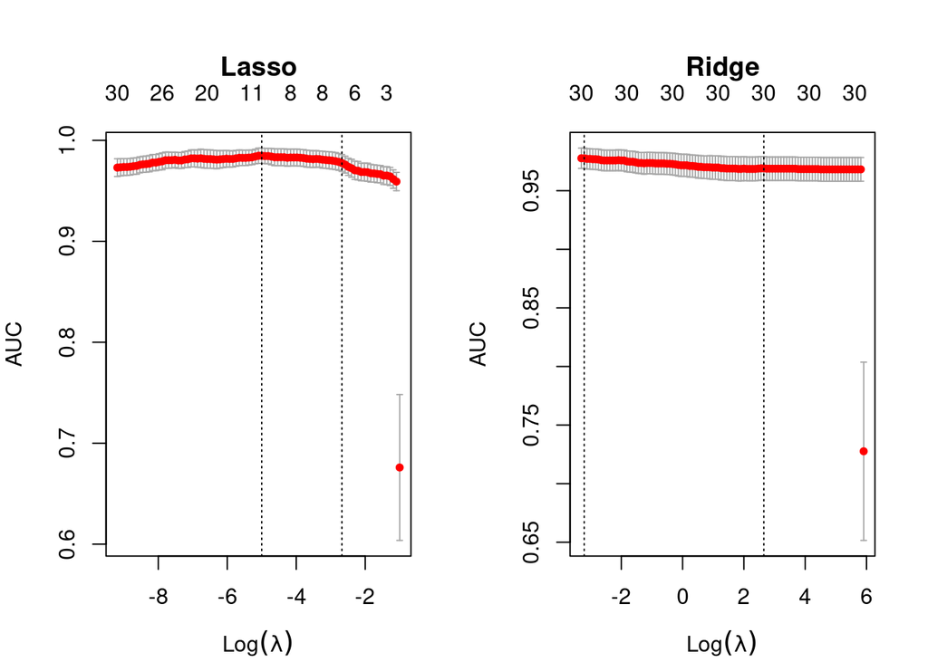

```r
library(magrittr)


set.seed(984065)

#Read the file as required

breast_cancer<- fread("assignment2/wdbc2.csv", sep =',',
                  stringsAsFactors = T)

# Change the diagnosis factor to a numerical value
breast_cancer$diagnosis = as.numeric(breast_cancer$diagnosis, levels=c('benign', 'malignant'), labels=c(0, 1))
breast_cancer$diagnosis[breast_cancer$diagnosis == 1 ] =0
breast_cancer$diagnosis[breast_cancer$diagnosis == 2 ] =1


# we split into 70% training and 30% testing data
split_index <- createDataPartition(breast_cancer$diagnosis,
                                  p = .7, list = FALSE, times = 1)


#train and test data sets
train_breast_cancer <- breast_cancer[split_index, ]
test_breast_cancer <- breast_cancer[-split_index, ]

#-- We first prepare the training data

# Input matrix
biomarkers_matrix.x <- as.matrix(subset(train_breast_cancer, select = -c(id, diagnosis)))

biomakers_matrix_predictors.y <- as.matrix(subset(train_breast_cancer, select = c(diagnosis)))



#  We fit the ridge regression on training data
fit.ridge = cv.glmnet(biomarkers_matrix.x, biomakers_matrix_predictors.y , alpha = 0, family = "binomial", type.measure="auc")


# We fit the Lasso regression on training data

fit.lasso = cv.glmnet(biomarkers_matrix.x, biomakers_matrix_predictors.y , alpha = 1, family = "binomial", type.measure="auc")

par(mfrow=c(1,2), mar=c(4,4,5,2))
plot(fit.lasso, main="Lasso")
plot(fit.ridge, main="Ridge")
```

```r
cat("The values of lambda for lasso that maximises the AUC is:", fit.lasso$lambda.min,"\n")
```

```
## The values of lambda for lasso that maximises the AUC is: 0.006732317
```

```r
cat("The values of lambda for ridge that maximises the AUC is:", fit.ridge$lambda.min,"\n")
```

```
## The values of lambda for ridge that maximises the AUC is: 0.04035918
```

From the plots we can see that the best AUC for Lasso is obtained approximately in log(lambda) = -5 (i.e. exp(-5)), and for the Ridge regression in log(lambda) - -3 (i.e. exp(-3)). These are approximate values only. ### Problem 1.b (2 points)

Create a data table that for each value of ‘lambda.min’ and ‘lambda.1se’ for each model fitted in problem 1.a reports: * the corresponding AUC, * the corresponding model size. Use 3 significant digits for floating point values and comment on these results. Hint: The AUC values are stored in the field called ‘cvm’.

```r
#Our Lambdas

lambdamin.lasso = fit.lasso$lambda.min
lambdamin.ridge = fit.ridge$lambda.min

# We will need to find the position at which lambda min is located at lambda

index_lambdamin.lasso= which(lambdamin.lasso ==fit.lasso$lambda)
index_lambdamin.ridge= which(lambdamin.ridge ==fit.ridge$lambda)

#Now we find the position at which lambda lse is located


#lambda lse is the largest value of lambda that is located within 1 standard error

lambda1se.lasso = fit.lasso$lambda.1se
lambda1se.ridge = fit.ridge$lambda.1se

# We will need to find the position at which lambda lse is located at lambda
index_lambda1se.lasso= which(lambda1se.lasso ==fit.lasso$lambda)
index_lambda1se.ridge= which(lambda1se.ridge ==fit.ridge$lambda)

#We can find the corresponding AUC's

AUC.lambdamin.lasso = signif(fit.lasso$cvm[index_lambdamin.lasso],3)
AUC.lambda1se.lasso = signif(fit.lasso$cvm[index_lambda1se.lasso],3)

AUC.lambdamin.ridge = signif(fit.ridge$cvm[index_lambdamin.ridge],3)
AUC.lambda1se.ridge = signif(fit.ridge$cvm[index_lambda1se.ridge],3)

AUC.lambdamin.lasso
```

```
## [1] 0.985
```

```r
AUC.lambda1se.lasso
```

```
## [1] 0.978
```

```r
AUC.lambdamin.ridge
```

```
## [1] 0.978
```

```r
AUC.lambda1se.ridge
```

```
## [1] 0.969
```

```r
#We make  a table:

table1 <-data.table(model = c("Lasso (min)", "Lasso (1se)", "Ridge  (min)", "Ridge (1se)"),Lambda = c(lambdamin.lasso,lambda1se.lasso,lambdamin.ridge,lambda1se.ridge ), AUC = c(AUC.lambdamin.lasso,AUC.lambda1se.lasso,AUC.lambdamin.ridge,AUC.lambda1se.ridge))

table1
```

```
##           model       Lambda   AUC
## 1:  Lasso (min)  0.006732317 0.985
## 2:  Lasso (1se)  0.068907355 0.978
## 3: Ridge  (min)  0.040359182 0.978
## 4:  Ridge (1se) 14.170882485 0.969
```

### Problem 1.c (7 points)

Perform both backward (we’ll later refer to this as model B) and forward (model S) stepwise selection on the same training set derived in problem 1.a. Report the variables selected and their standardized regression coefficients in decreasing order of the absolute value of their standardized regression coefficient. Discuss the results and how the different variables entering or leaving the model influenced the final result.

```r
library(dplyr)
```

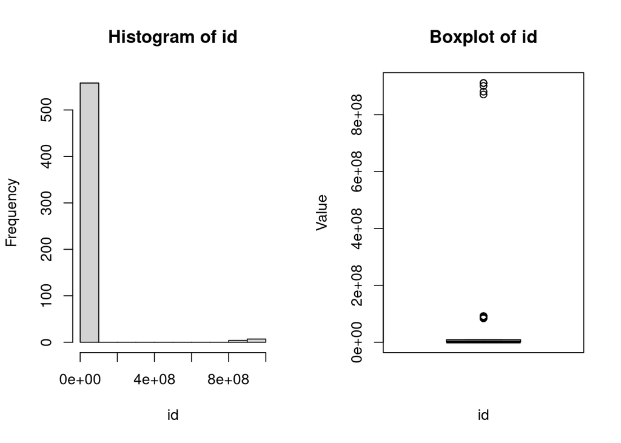

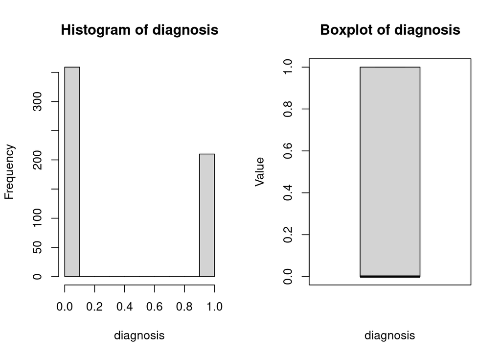

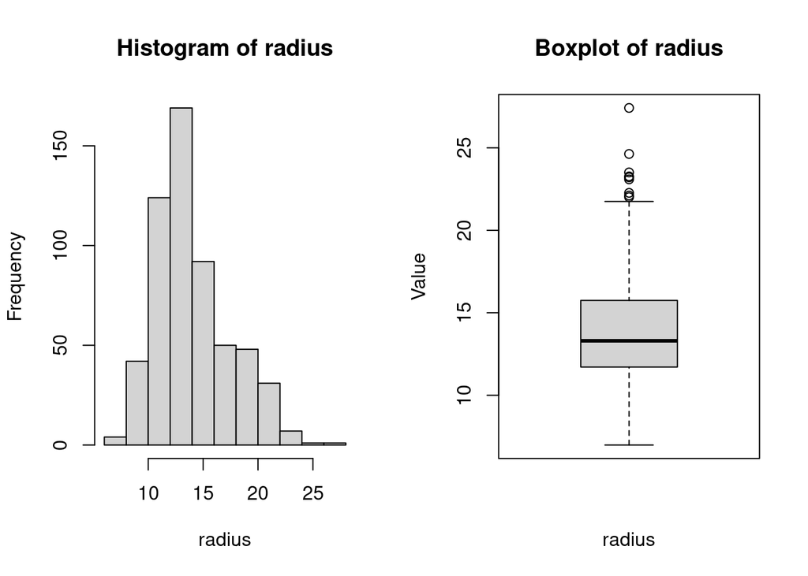

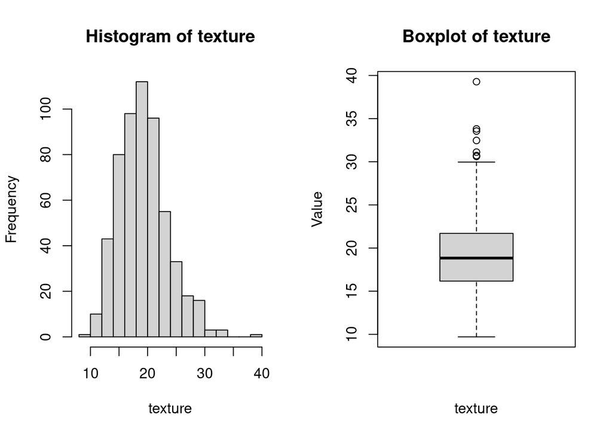

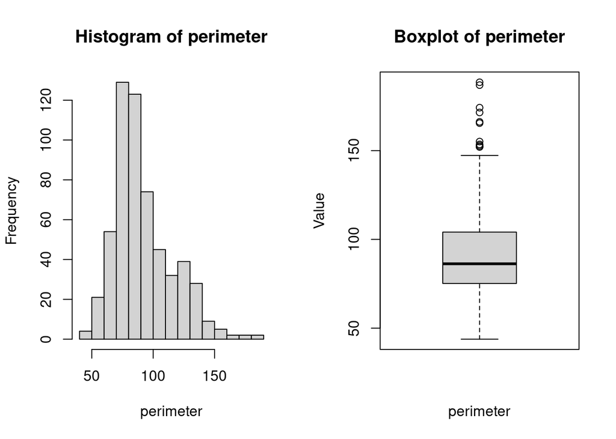

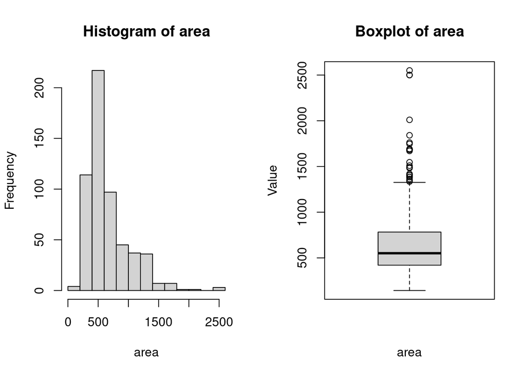

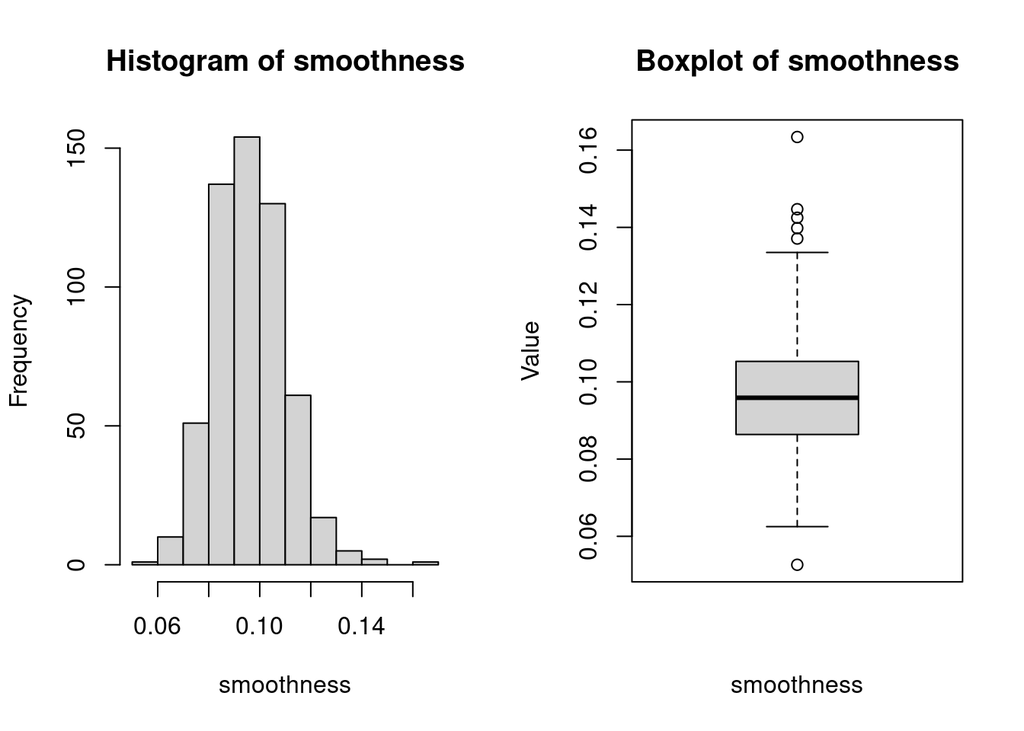

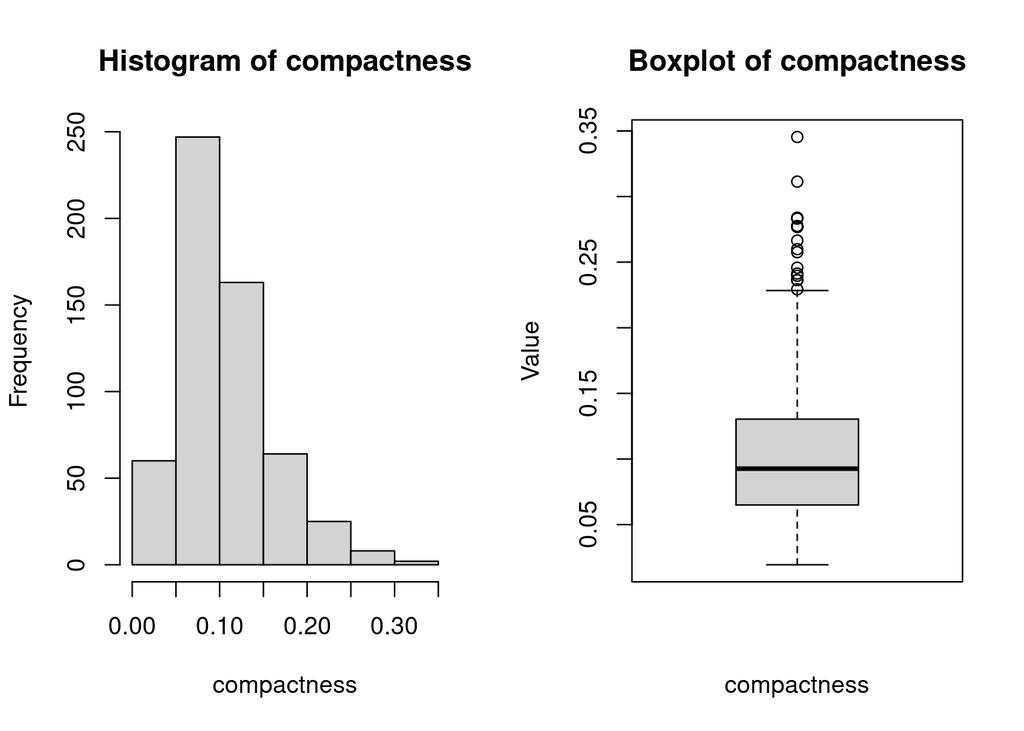

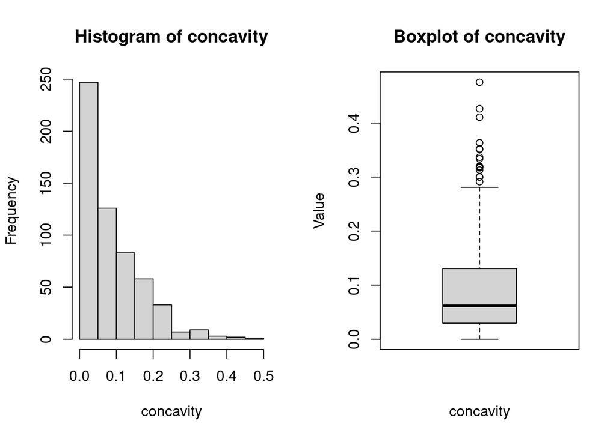

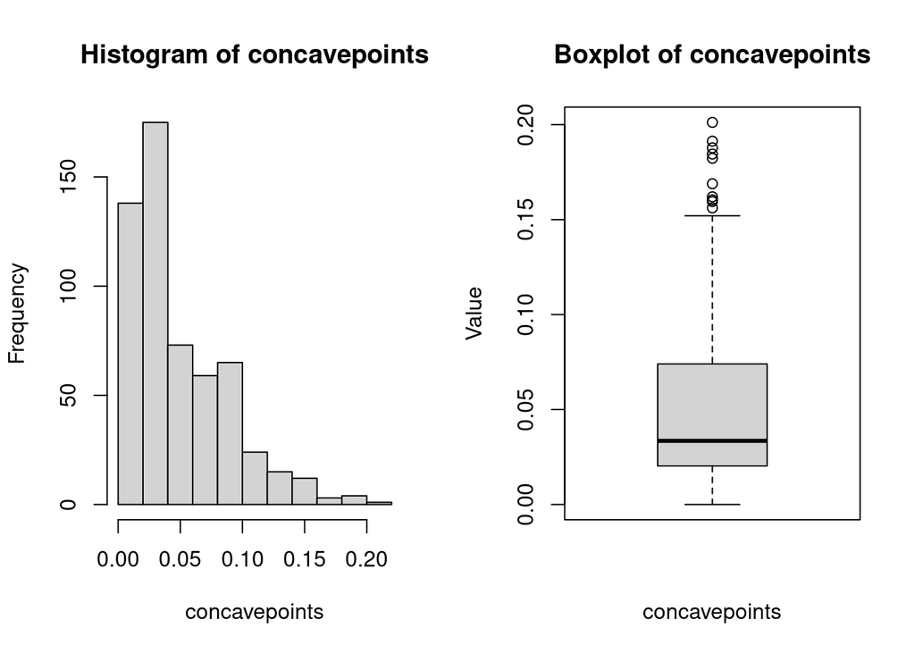

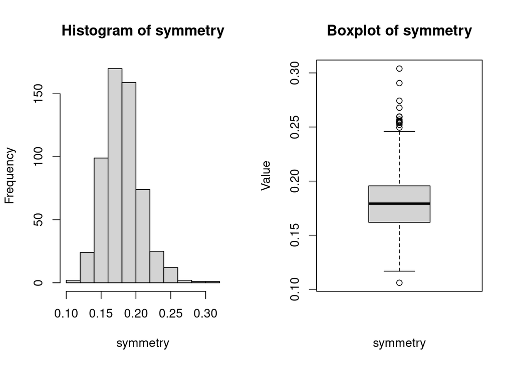

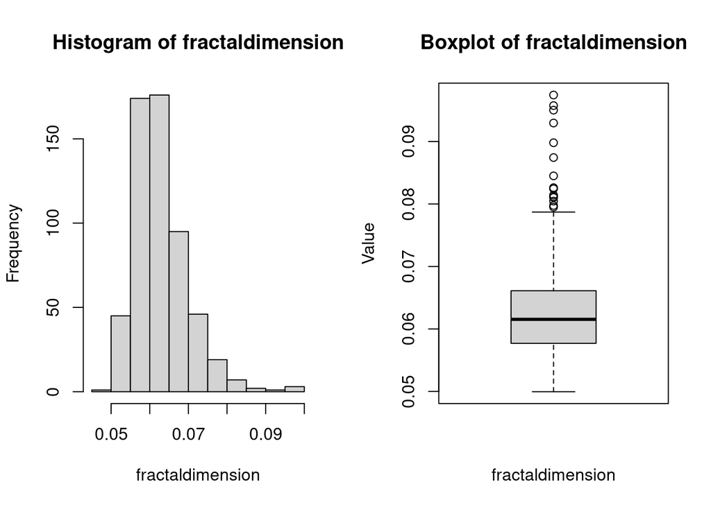

[20 more figures not shown]

[output not shown]

```r
library(knitr)

sbsplot <- function(varname, vars){
  par(mfrow = c(1,2))

  hist(vars[,varname],
       main = paste0("Histogram of ", varname),xlab = varname)
  boxplot(vars[,varname],
       main = paste0("Boxplot of ", varname),xlab = varname,
       ylab = "Value")

}

# We make a histogram and bar plot just to see which predictors are the best
numcols = breast_cancer %>% select_if(is.numeric) %>% colnames
sapply(numcols, sbsplot, vars = data.frame(breast_cancer))
```

```r
#We define full model, null model

full_model <- glm(diagnosis~., data = train_breast_cancer)

Null_model <- glm(diagnosis~1, data = train_breast_cancer)
```

```r
#Backward Selection
library(MASS)
Model_B<- stepAIC(full_model, direction = "back")
```

```
## Start:  AIC=80.26
## diagnosis ~ id + radius + texture + perimeter + area + smoothness +
##     compactness + concavity + concavepoints + symmetry + fractaldimension +
##     radius.stderr + texture.stderr + perimeter.stderr + area.stderr +
##     smoothness.stderr + compactness.stderr + concavity.stderr +
##     concavepoints.stderr + symmetry.stderr + fractaldimension.stderr +
##     radius.worst + texture.worst + perimeter.worst + area.worst +
##     smoothness.worst + compactness.worst + concavity.worst +
##     concavepoints.worst + symmetry.worst + fractaldimension.worst
##
##                           Df Deviance    AIC
## - fractaldimension.stderr  1   24.211 78.256
## - symmetry.stderr          1   24.211 78.257
## - concavepoints.stderr     1   24.211 78.258
## - concavity                1   24.212 78.263
## - area.stderr              1   24.212 78.276
## - compactness.worst        1   24.214 78.296
## - smoothness               1   24.215 78.318
## - area                     1   24.215 78.327
## - texture                  1   24.220 78.397
## - perimeter.worst          1   24.220 78.397
## - texture.stderr           1   24.224 78.473
## - concavepoints.worst      1   24.230 78.574
## - compactness.stderr       1   24.235 78.650
## - symmetry                 1   24.238 78.704
## - fractaldimension         1   24.241 78.744
## - perimeter.stderr         1   24.245 78.807
## - id                       1   24.251 78.913
## - concavity.worst          1   24.260 79.055
## - smoothness.worst         1   24.267 79.173
## - concavity.stderr         1   24.278 79.358
## - smoothness.stderr        1   24.280 79.397
## - texture.worst            1   24.289 79.536
## <none>                         24.211 80.256
## - symmetry.worst           1   24.382 81.063
## - radius.worst             1   24.396 81.284
## - fractaldimension.worst   1   24.396 81.286
## - compactness              1   24.403 81.401
## - radius.stderr            1   24.414 81.584
## - perimeter                1   24.623 84.984
```

[output cut: 547 more lines]

```
## <none>                        24.594 52.522
## - concavity.stderr        1   24.783 53.568
## - concavity.worst         1   24.863 54.860
## - compactness.stderr      1   24.972 56.602
## - symmetry.worst          1   25.153 59.489
## - smoothness.stderr       1   25.160 59.586
## - perimeter               1   25.257 61.126
## - fractaldimension.worst  1   25.276 61.432
## - compactness             1   25.348 62.562
## - radius.stderr           1   25.738 68.656
## - radius                  1   25.783 69.352
## - concavepoints           1   25.828 70.043
## - texture.worst           1   25.870 70.696
## - radius.worst            1   25.878 70.819
## - area.worst              1   26.442 79.420
```

```r
#Forward Selection

Model_S<- stepAIC(Null_model,scope = list(upper = full_model), direction ="forward")
```

```
## Start:  AIC=556.76
## diagnosis ~ 1
##
##                           Df Deviance    AIC
## + concavepoints.worst      1   39.401 214.56
## + concavepoints            1   40.620 226.72
## + perimeter.worst          1   40.634 226.86
## + radius.worst             1   41.657 236.77
## + perimeter                1   44.960 267.22
## + radius                   1   45.009 267.65
## + concavity                1   46.527 280.89
## + area.worst               1   46.864 283.77
## + area                     1   50.136 310.69
## + concavity.worst          1   50.482 313.44
## + area.stderr              1   55.244 349.41
## + radius.stderr            1   58.015 368.93
## + perimeter.stderr         1   59.413 378.44
## + compactness              1   61.101 389.62
## + compactness.worst        1   61.771 393.97
## + concavepoints.stderr     1   74.384 468.10
## + texture.worst            1   74.652 469.54
## + symmetry.worst           1   75.640 474.79
## + texture                  1   77.192 482.89
## + smoothness.worst         1   79.726 495.78
## + compactness.stderr       1   81.361 503.88
## + symmetry                 1   81.875 506.39
## + smoothness               1   82.711 510.44
## + fractaldimension.worst   1   83.818 515.75
## + concavity.stderr         1   84.595 519.43
## + fractaldimension.stderr  1   91.041 548.73
## <none>                         93.358 556.76
## + symmetry.stderr          1   93.161 557.91
## + smoothness.stderr        1   93.180 557.99
## + texture.stderr           1   93.212 558.13
## + id                       1   93.292 558.48
## + fractaldimension         1   93.349 558.72
##
## Step:  AIC=214.56
## diagnosis ~ concavepoints.worst
##
```

[output cut: 437 more lines]

```
## + smoothness.stderr        1   24.512 55.191
## + concavepoints.stderr     1   24.533 55.522
## + fractaldimension.stderr  1   24.540 55.644
## + symmetry                 1   24.547 55.759
## + texture                  1   24.550 55.805
## + perimeter.worst          1   24.554 55.864
## + compactness.worst        1   24.557 55.920
## + concavity                1   24.559 55.945
## + id                       1   24.563 56.009
## + area                     1   24.564 56.027
## + smoothness               1   24.564 56.031
## + fractaldimension         1   24.566 56.065
## + symmetry.stderr          1   24.573 56.184
## + texture.stderr           1   24.575 56.206
## + compactness.stderr       1   24.575 56.209
```

The forward model takes a null model(which is a model without any feature) and only considers the intercept as a starting point and then progress towards the full model (with 30 features) by adding features. It can be seen here that the final model (forward) considers more features than the backward model. The forward model considers 15 features instead of 14 (in the backwards model)

```r
#Summary

summary(Model_B)
```

```
##
## Call:
## glm(formula = diagnosis ~ radius + perimeter + compactness +
##     concavepoints + radius.stderr + smoothness.stderr + compactness.stderr +
##     concavity.stderr + radius.worst + texture.worst + area.worst +
##     concavity.worst + symmetry.worst + fractaldimension.worst,
##     data = train_breast_cancer)
##
## Deviance Residuals:
##      Min        1Q    Median        3Q       Max
## -1.00848  -0.17672  -0.02864   0.14058   0.95019
##
## Coefficients:
##                          Estimate Std. Error t value Pr(>|t|)
## (Intercept)            -2.3003927  0.2425482  -9.484  < 2e-16 ***
## radius                  0.0743984  0.0172705   4.308 2.10e-05 ***
## perimeter              -0.0111032  0.0034525  -3.216 0.001410 **
## compactness            -2.5826629  0.7529731  -3.430 0.000669 ***
## concavepoints           5.3127566  1.2107301   4.388 1.48e-05 ***
## radius.stderr           0.4256226  0.1007265   4.226 2.98e-05 ***
## smoothness.stderr      16.9805981  5.7165359   2.970 0.003161 **
## compactness.stderr     -3.8819567  1.5987020  -2.428 0.015633 *
## concavity.stderr        0.9488969  0.5530813   1.716 0.087032 .
## radius.worst            0.1408605  0.0314660   4.477 1.00e-05 ***
## texture.worst           0.0105318  0.0023600   4.463 1.07e-05 ***
## area.worst             -0.0009868  0.0001837  -5.371 1.36e-07 ***
## concavity.worst         0.3504861  0.1710681   2.049 0.041160 *
## symmetry.worst          0.8536208  0.2889478   2.954 0.003327 **
## fractaldimension.worst  4.7503948  1.4559903   3.263 0.001203 **
## ---
## Signif. codes:  0 '***' 0.001 '**' 0.01 '*' 0.05 '.' 0.1 ' ' 1
##
## (Dispersion parameter for gaussian family taken to be 0.06404781)
##
##     Null deviance: 93.358  on 398  degrees of freedom
## Residual deviance: 24.594  on 384  degrees of freedom
## AIC: 52.522
##
## Number of Fisher Scoring iterations: 2
```

```r
summary(Model_S)
```

```
##
## Call:
## glm(formula = diagnosis ~ concavepoints.worst + radius + texture.worst +
##     radius.stderr + area.stderr + smoothness.worst + symmetry.worst +
##     perimeter.stderr + concavity.worst + compactness + concavepoints +
##     fractaldimension.worst + area.worst + radius.worst + perimeter,
##     data = train_breast_cancer)
##
## Deviance Residuals:
##     Min       1Q   Median       3Q      Max
## -0.9743  -0.1720  -0.0246   0.1354   0.9356
##
## Coefficients:
##                          Estimate Std. Error t value Pr(>|t|)
## (Intercept)            -2.2713307  0.2519678  -9.014  < 2e-16 ***
## concavepoints.worst    -0.7037566  0.7687075  -0.916  0.36050
## radius                  0.0856111  0.0174251   4.913 1.33e-06 ***
## texture.worst           0.0108587  0.0023721   4.578 6.37e-06 ***
## radius.stderr           0.9152699  0.3103114   2.950  0.00338 **
## area.stderr            -0.0007198  0.0023919  -0.301  0.76362
## smoothness.worst        2.4703766  0.8976430   2.752  0.00620 **
## symmetry.worst          0.7768531  0.2873158   2.704  0.00716 **
## perimeter.stderr       -0.0503778  0.0308309  -1.634  0.10308
## concavity.worst         0.4276025  0.1579741   2.707  0.00710 **
## compactness            -2.9706608  0.7141464  -4.160 3.94e-05 ***
## concavepoints           5.8623031  1.3875906   4.225 2.99e-05 ***
## fractaldimension.worst  3.3772683  1.4952962   2.259  0.02447 *
## area.worst             -0.0008448  0.0002321  -3.640  0.00031 ***
## radius.worst            0.1106887  0.0346149   3.198  0.00150 **
## perimeter              -0.0102155  0.0037572  -2.719  0.00685 **
## ---
## Signif. codes:  0 '***' 0.001 '**' 0.01 '*' 0.05 '.' 0.1 ' ' 1
##
## (Dispersion parameter for gaussian family taken to be 0.06416889)
##
##     Null deviance: 93.358  on 398  degrees of freedom
## Residual deviance: 24.577  on 383  degrees of freedom
## AIC: 54.235
##
## Number of Fisher Scoring iterations: 2
```

```r
#Regression Coeifficients in decreasing order

modelB.coef1 <-Model_B$coefficients
sort_modelB.coef1<- order(abs(modelB.coef1), decreasing = TRUE)

modelS.coef1 <-Model_S$coefficients
sort_modelS.coef1<- order(abs(modelS.coef1), decreasing = TRUE)


kable(list(modelB.coef1[sort_modelB.coef1], modelS.coef1[sort_modelS.coef1]),col.names = "Coefficients")
```

|  | Coefficients |
| --- | --- |
| smoothness.stderr | 16.9805981 |
| concavepoints | 5.3127566 |
| fractaldimension.worst | 4.7503948 |
| compactness.stderr | -3.8819567 |
| compactness | -2.5826629 |
| (Intercept) | -2.3003927 |
| concavity.stderr | 0.9488969 |
| symmetry.worst | 0.8536208 |
| radius.stderr | 0.4256226 |
| concavity.worst | 0.3504861 |
| radius.worst | 0.1408605 |
| radius | 0.0743984 |
| perimeter | -0.0111032 |
| texture.worst | 0.0105318 |
| area.worst | -0.0009868 |

|  | Coefficients |
| --- | --- |
| concavepoints | 5.8623031 |
| fractaldimension.worst | 3.3772683 |
| compactness | -2.9706608 |
| smoothness.worst | 2.4703766 |
| (Intercept) | -2.2713307 |
| radius.stderr | 0.9152699 |
| symmetry.worst | 0.7768531 |
| concavepoints.worst | -0.7037566 |
| concavity.worst | 0.4276025 |
| radius.worst | 0.1106887 |
| radius | 0.0856111 |
| perimeter.stderr | -0.0503778 |
| texture.worst | 0.0108587 |
| perimeter | -0.0102155 |
| area.worst | -0.0008448 |
| area.stderr | -0.0007198 |

The AIC in the forward and the backward model are different, but not by a great amount. The AIC in the backward model is 52.52 while the AIC in the forward model is 54.23. The difference between them is a reflection of the number of features considered for each model.

### Problem 1.d (3 points)

Compare the goodness of fit of model B and model S in an appropriate way.

```r
cat("deviance of model B = ", Model_B$deviance, "\n") #cat eye
```

```
## deviance of model B =  24.59436
```

```r
cat("deviance of model S = ", Model_S$deviance, "\n")
```

```
## deviance of model S =  24.57668
```

```r
#It just means that adding additional terms to null model is reasonable

pchisq(Model_B$null.deviance - Model_B$deviance, df =15, lower.tail =FALSE)
```

```
## [1] 7.40918e-09
```

```r
pchisq(Model_S$null.deviance - Model_S$deviance, df = 16, lower.tail = FALSE)
```

```
## [1] 1.629431e-08
```

### Problem 1.e (2 points)

Compute the training AUC for model B and model S.

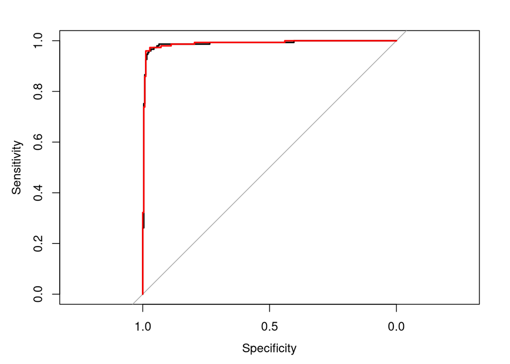

```r
library(pROC)

train.AUC.model_B = roc(train_breast_cancer$diagnosis, Model_B$fitted.values, plot =TRUE)

train.AUC.model_S = roc(train_breast_cancer$diagnosis, Model_S$fitted.values, plot = TRUE, add= TRUE,col = "red")
```

### Problem 1.f (6 points)

Use the four models to predict the outcome for the observations in the test set (use the lambda at 1 standard error for the penalised models). Plot the ROC curves of these models (on the sameplot, using different colours) and report their test AUCs. Compare the training AUCs obtained in problems 1.b and 1.e with the test AUCs and discuss the fit of the different models.

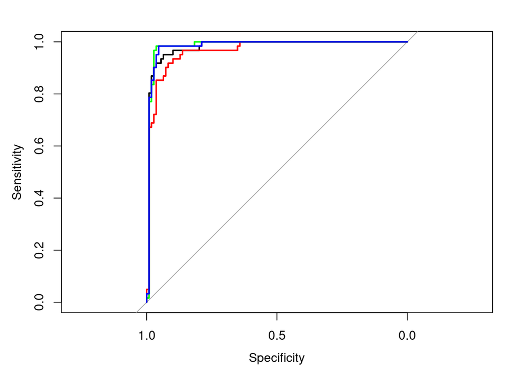

```r
#Lasso model

pred_lasso = predict(fit.lasso, newx = as.matrix(test_breast_cancer[,-c(1,2)]),s="lambda.1se")

#Ridge Regression model

pred_ridge = predict(fit.ridge, newx = as.matrix(test_breast_cancer[,-c(1,2)]),s="lambda.1se")

#Model B

pred_modelB = predict(Model_B, newdata = test_breast_cancer, type = "response")

#Model S

pred_modelS = predict(Model_S, newdata = test_breast_cancer, type = "response")

#Now we plot the ROC curves

AUC_lasso = roc(test_breast_cancer$diagnosis, pred_lasso, plot =TRUE, col = "black")$auc
AUC_ridge = roc(test_breast_cancer$diagnosis, pred_ridge, plot =TRUE, col = "red",add= TRUE)$auc
AUC_modelB = roc(test_breast_cancer$diagnosis, pred_modelB, plot =TRUE, col = "green",add= TRUE)$auc
AUC_modelS =  roc(test_breast_cancer$diagnosis, pred_modelS, plot =TRUE, col = "blue",add= TRUE)$auc
```

```r
#Compare the AUCs

training_AUC = c(AUC.lambda1se.lasso, AUC.lambda1se.ridge,train.AUC.model_B$auc, train.AUC.model_S$auc)

testing_AUC = c(AUC_lasso, AUC_ridge, AUC_modelB, AUC_modelS)

Final_models = c("Lasso Model", "Ridge Regression Model", "Model B", "Model S")

# We make a table and voila!

table = data.table(Final_models, training_AUC, testing_AUC)
kable(table)
```

| Final_models | training_AUC | testing_AUC |
| --- | --- | --- |
| Lasso Model | 0.9780000 | 0.9798466 |
| Ridge Regression Model | 0.9690000 | 0.9658595 |
| Model B | 0.9886980 | 0.9846593 |
| Model S | 0.9894228 | 0.9837570 |

We can see that the Area Under the Curve(AUC)’s obtained for all 4 models are similar, all have auc > 0.95, which tells that they can all distinguish between tumors - benign and malignant. For the training and testing AUC’s we can see that AUC’s are fairly similar between training and testing for Ridge Regression Model, Model B and Model S. We can also see that Model S has higher training AUC than Model B and subsequently higher than Lasso and Rigde, it falls behind Model B when we find testing AUC. Thus, the best model is the backward model for this particular case as it relates better to expected task of the model which is to determine whether a tumor is malignant or not.

## Problem 2 (40 points)

File GDM.raw.txt (available from the accompanying zip folder on Learn) contains 176 SNPs to be studied for association with incidence of gestational diabetes (a form of diabetes that is specific to pregnant women). SNP names are given in the form “rs1234_X” where “rs1234” is the official identifier (rsID), and “X” (one of A, C, G, T) is the reference allele.

### Problem 2.a (3 points)

Read file GDM.raw.txt into a data table named gdm.dt. Impute missing values in gdm.dt according to SNP-wise median allele count.

```r
GDM <-fread("assignment2/GDM.raw.txt")

gdm.dt <- data.table(GDM)

#Impute to median function(Inspired from Lab4)

for (colnm in colnames(gdm.dt,-1)) {
gdm.dt[[colnm]][is.na(gdm.dt[[colnm]])] <-
median(gdm.dt[[colnm]], na.rm = T)
}

gdm.dt
```

```
##        ID   sex pheno rs7513574_T rs1627238_A rs1171278_C rs1137100_A
##   1:    1 FALSE     0           1           0           0           2
##   2:    2 FALSE     0           0           0           0           1
##   3:    4 FALSE     1           2           1           1           1
##   4:    5 FALSE     1           0           1           1           1
##   5:    6 FALSE     1           0           1           1           1
##  ---
## 785: 1054 FALSE     0           0           1           1           1
## 786: 1055 FALSE     0           0           0           0           0
## 787: 1056 FALSE     1           1           0           0           1
## 788: 1058 FALSE     0           1           0           0           1
## 789: 1059 FALSE     1           1           0           0           1
##      rs2568958_A rs1514175_A rs1555543_C rs10923931_C rs516636_A rs574367_G
##   1:           0           1           2            0          0          0
##   2:           0           0           1            0          1          0
```

[output cut: 345 more lines]

### Problem 2.b (8 points)

Write function univ.glm.test <- function(x, y, order = FALSE) where x is a data table of SNPs, y is a binary outcome vector, and order is a boolean. The function should fit a logistic regression model for each SNP in x, and return a data table containing SNP names, regression coefficients, odds ratios, standard errors and p-values. If order is set to TRUE, the output data table should be ordered by increasing p-value.

```r
#We make a univ.glm.test
univ.glm.test <- function(x, y, order = FALSE) {
  if (dim(x)[1]  != length(y)){
    stop("Length of x and y do not match - check dimensions")

  }
  else{
    n = dim(x)[2]
    output = data.table(
      "SNP_name " = character(),
      "beta" = numeric(),
      "odds_ratio" = numeric(),
      "standard_error" = numeric(),
      "p_value" = numeric()
    )

    for(i in 1:n){
    regr = glm(y~x[[i]], family = binomial(link = "logit"))
    regr.sum = coef(summary(regr))
    output = rbind(output,
                   list(names(x)[i],
                   regr.sum[2,1],
                   exp(regr.sum[2,1]),
                   regr.sum[2,2],
                   regr.sum[2,4]))

  }

  }
  if(order){
    output = output[order(p.value)]
  }

  return(output)
}
```

### Problem 2.c (5 points)

Using function univ.glm.test(), run an association study for all the SNPs in gdm.dt against having gestational diabetes (column “pheno”). For the SNP that is most strongly associated to increased risk of gestational diabetes and the one with most significant protective effect, report the summary statistics from the GWAS as well as the 95% and 99% confidence intervals on the odds ratio.

```r
#Association Study

x = gdm.dt[,-c(1,2,3)]
dim(x)[2]
```

```
## [1] 176
```

```r
pheno = gdm.dt[[3]]

final = univ.glm.test(x = x, y = pheno)

#Representaton of our our association study

head(final)
```

```
##      SNP_name         beta odds_ratio standard_error   p_value
## 1: rs7513574_T 0.002157494   1.002160      0.1051372 0.9836280
## 2: rs1627238_A 0.114637864   1.121467      0.1138224 0.3138559
## 3: rs1171278_C 0.121409445   1.129087      0.1138073 0.2860628
## 4: rs1137100_A 0.060104751   1.061948      0.1104238 0.5862285
## 5: rs2568958_A 0.149379896   1.161114      0.1233800 0.2259989
## 6: rs1514175_A 0.056229626   1.057841      0.1052359 0.5931203
```

```r
#The most strongly associated SNP to increased risk of gestational diabetes

index = which(final$odds_ratio == max(final$odds_ratio))
strongest_assos = final[index, ]

# Calculate confidence intervals - 95% and 99%

reg_coeff_risk <- strongest_assos$beta
std.reg_coeff_risk = strongest_assos$standard_error
confint_95_risk = round(exp(reg_coeff_risk +1.96* reg_coeff_risk*c(-1,1)),3)
confint_99_risk = round(exp(reg_coeff_risk +2.576*reg_coeff_risk*c(-1,1)),3)

#We need to check which SNP which reduce the risk of gestational diabetes, it means we need to find SNP(s) with odds-ratio lower than 1

# We will check for SNPs with odds <1
newindex = which(final$odds_ratio <1)
best = final[newindex,]

# Select the SNP with lowest p value
index3 = which(best$p_value == min(best$p_value))
best_SNP = best[index3]


#We now find the confidence interval for odds ratio

beta2 = best_SNP$beta
standard_error2 = best_SNP$standard_error
new_confidence_interval1 = round(exp(beta2 +1.96*standard_error2 *c(-1,1)),3)
new_confidence_interval2 = round(exp(beta2 +2.576*standard_error2 *c(-1,1)),3)

#Output


cat(" SNP most strongly associated to increased risk of gestational     diabetes is", strongest_assos$SNP_name, "\n odds ratio is", strongest_assos$odds_ratio, "\n p value", strongest_assos$p_value,"\n 95% Confidence Inteval = ", confint_95_risk, "\n 99% Confidence Interval = ", confint_99_risk )
```

```
##  SNP most strongly associated to increased risk of gestational     diabetes is rs1423096_T
##  odds ratio is 1.91758
##  p value 0.03977583
##  95% Confidence Inteval =  0.535 6.87
##  99% Confidence Interval =  0.358 10.26
```

```r
cat("\n SNPs with most protective effect is", best_SNP$SNP_name, "\n odds_ratio = ", best_SNP$odds_ratio, "\n p_value = ", best_SNP$p_value,"\n 95% Confidence Inteval = ", new_confidence_interval1, "\n 99% Confidence Interval = ", new_confidence_interval2)
```

```
##
##  SNPs with most protective effect is rs2237897_T
##  odds_ratio =  0.6443936
##  p_value =  9.530178e-05
##  95% Confidence Inteval =  0.517 0.804
##  99% Confidence Interval =  0.482 0.861
```

We can see that SNP rs1423096_T has the highest odds ratio (1.91758) and hence is the most strongly associated to increased risk of gestational diabetes. In fact, this SNP increases the odds of having gestational diabetes by about 92!. The SNP with most significant protective effect is rs2237897_T and it reduced the risk of diabetes by about 35%. ### Problem 2.d (4points)

Merge your GWAS results with the table of gene names provided in file GDM.annot.txt (available from the accompanying zip folder on Learn). For SNPs that have p-value $< 10^{-4}$ (hit SNPs) report SNP name, effect allele, chromosome number and corresponding gene name. Separately, report for each ‘hit SNP’ the names of the genes that are within a 1Mb window from the SNP position on the chromosome. Note: That’s genes that fall within +/- 1,000,000 positions using the ‘pos’ column in the dataset.

```r
#Read the gene name data file
gene_names = fread("assignment2/GDM.annot.txt")

#create a new matrix
final[,c("snp", "allele"):=tstrsplit(`SNP_name `, "_", fixed = TRUE)]


#create a merged data table using inner join
merged.dt = merge(gene_names, final)


#Hit SNP
hit.SNP = merged.dt[p_value<1e-4]

#Output table with SNP name, allele, chromosome number, gene name for hit_SNPs

kable(hit.SNP[,c("snp", "beta","allele","chrom", "gene")])
```

| snp | beta | allele | chrom | gene |
| --- | --- | --- | --- | --- |
| rs12243326 | 0.6454198 | A | 10 | TCF7L2 |
| rs2237897 | -0.4394456 | T | 11 | KCNQ1 |

```r
#Separately, report for each 'hit SNP' the names of the genes that are within a 1Mb window from the SNP position on the chromosome. Note: That's genes that fall within +/- 1,000,000 positions using the 'pos' column in the dataset.


#1,000,000 positions = 1e6

threshold <- 1e6

hit.snp_window <- data.table()

for (i in hit.SNP$snp){
  idx = which(hit.SNP$snp == i)
  window_values <- merged.dt[(merged.dt$pos>= hit.SNP$pos[idx] - threshold) & (merged.dt$pos<= hit.SNP$pos[idx] + threshold)]
  hit.snp_window <- rbind(hit.snp_window, window_values)
}

# Display the genes that fall within this window
kable(data.table(hit.snp_window$gene), col.names = "Thereshold below 1,000,000")
```

| Thereshold below 1,000,000 |
| --- |
| TCF7L2 |
| TCF7L2 |
| TCF7L2 |
| TCF7L2 |
| TH |
| KCNQ1 |
| CACNA2D4 |
| KCNQ1 |
| KCNQ1 |
| KCNQ1 |
| SMG6 |
| SMG6 |

### Problem 2.e (8 points)

Build a weighted genetic risk score that includes all SNPs with p-value $< 10^{-4}$, a score with all SNPs with p-value $< 10^{-3}$, and a score that only includes SNPs on the FTO gene (hint: ensure that the ordering of SNPs is respected). Add the three scores as columns to the gdm.dt data table. Fit the three scores in separate logistic regression models to test their association with gestational diabetes, and for each report odds ratio, 95% confidence interval and p-value.

```r
#Weighted genetic risk score

#This is our score 1(1e-4)
gdm.grs = gdm.dt[, .SD, .SDcols = merged.dt[p_value <1e-4]$`SNP_name `]
snp.grs = merged.dt[p_value <1e-4]
weighted.score1 = as.matrix(gdm.grs)%*% snp.grs$beta

#This is our score 2(1e-3)
gdm.grs2 = gdm.dt[, .SD, .SDcols = merged.dt[p_value <1e-3]$`SNP_name `]
snp.grs2 = merged.dt[p_value <1e-3]
weighted.score2 = as.matrix(gdm.grs2)%*% snp.grs2$beta

#This is our score 3 (FTO gene)
gdm.grs3 = gdm.dt[, .SD, .SDcols = merged.dt[gene =="FTO"]$`SNP_name `]
snp.grs3 = merged.dt[gene == "FTO"]
weighted.score3 = as.matrix(gdm.grs3)%*% snp.grs3$beta
```

```r
# We can automate the process
if(!("score1.V1" %in% colnames(gdm.dt))){

  helper = data.table(score1 = weighted.score1,
                      score2 = weighted.score2,
                      score3 = weighted.score3)

  gdm.dt = cbind(gdm.dt, helper)
}


 head(gdm.dt)
```

```
##    ID   sex pheno rs7513574_T rs1627238_A rs1171278_C rs1137100_A rs2568958_A
## 1:  1 FALSE     0           1           0           0           2           0
## 2:  2 FALSE     0           0           0           0           1           0
## 3:  4 FALSE     1           2           1           1           1           1
## 4:  5 FALSE     1           0           1           1           1           0
## 5:  6 FALSE     1           0           1           1           1           1
## 6:  7 FALSE     0           1           1           1           0           0
##    rs1514175_A rs1555543_C rs10923931_C rs516636_A rs574367_G rs543874_C
## 1:           1           2            0          0          0          0
## 2:           0           1            0          1          0          1
## 3:           1           2            0          0          0          0
## 4:           2           2            1          0          0          0
## 5:           0           0            0          0          0          0
## 6:           0           0            0          2          2          2
##    rs7554506_A rs340874_G rs2867125_A rs6548238_A rs7561317_C rs6545814_T
```

[output cut: 195 more lines]

```r
# Linear Regression Model
fit1 = glm(pheno ~score1.V1, family = binomial(link = "logit"), data = gdm.dt)

fit2 = glm(pheno ~score2.V1, family = binomial(link = "logit"), data = gdm.dt)

fit3 = glm(pheno ~score3.V1, family = binomial(link = "logit"), data = gdm.dt)

fit_all = c(fit1, fit2, fit3)
```

```r
# Find odds ratio, 95% confidence interval and p-value

beta1 = fit1$coefficients[2]
beta2 = fit2$coefficients[2]
beta3 = fit3$coefficients[2]

Standard_error_beta1 = coef(summary(fit1))[2,2]
Standard_error_beta2 = coef(summary(fit2))[2,2]
Standard_error_beta3 = coef(summary(fit3))[2,2]

#Confidence Intervals

Confidence_interval1  = round(exp(beta1 +1.96*Standard_error_beta1 *c(-1,1)),3)
Confidence_interval2 = round(exp(beta2 +1.96*Standard_error_beta2 *c(-1,1)),3)
Confidence_interval3 = round(exp(beta3 +1.96*Standard_error_beta3 *c(-1,1)),3)

#p_value

p_value1 = coef(summary(fit1))[2,4]
p_value2 = coef(summary(fit2))[2,4]
p_value3 = coef(summary(fit3))[2,4]


#Data table

temp = data.table(Score = c("score1", "score2", "score3"), Odds_ratio = c(exp(beta1), exp(beta2), exp(beta3)),
Confidence_interval =c(Confidence_interval1, Confidence_interval2, Confidence_interval3), p_value = c(p_value1, p_value2, p_value3))

kable(temp)
```

| Score | Odds_ratio | Confidence_interval | p_value |
| --- | --- | --- | --- |
| score1 | 2.729433 | 1.915 | 0.0000000 |
| score2 | 1.451854 | 3.890 | 0.0000000 |
| score3 | 1.413857 | 1.279 | 0.2151883 |
| score1 | 2.729433 | 1.648 | 0.0000000 |
| score2 | 1.451854 | 0.818 | 0.0000000 |
| score3 | 1.413857 | 2.445 | 0.2151883 |

### Problem 2.f (4 points)

File GDM.test.txt (available from the accompanying zip folder on Learn) contains genotypes of another 40 pregnant women with and without gestational diabetes (assume that the reference allele is the same one that was specified in file GDM.raw.txt). Read the file into variable gdm.test. For the set of patients in gdm.test, compute the three genetic risk scores as defined in problem 2.e using the same set of SNPs and corresponding weights. Add the three scores as columns to gdm.test (hint: use the same columnnames as before).

```r
#Read the data file
gdm_test = fread("assignment2/GDM.test.txt")


#We need to compute the three genetic risk scores that are defined in previous problem using the same set of SNPs and corresponding weights.

previous_snp1 = colnames(gdm.grs)
previous_snp1_updated = substr(previous_snp1, 1, nchar(previous_snp1)-2)
gdm_test.grs1 = gdm_test[,..previous_snp1_updated]
#previous weights
weight1 = snp.grs$beta
#Score
score_1 = as.matrix(gdm_test.grs1) %*% weight1

previous_snp2 = colnames(gdm.grs2)
previous_snp2_updated = substr(previous_snp2, 1, nchar(previous_snp2)-2)
gdm_test.grs2 = gdm_test[,..previous_snp2_updated]
#previous weights
weight2 = snp.grs2$beta
#Score
score_2= as.matrix(gdm_test.grs2) %*% weight2

previous_snp3 = colnames(gdm.grs3)
previous_snp3_updated = substr(previous_snp3, 1, nchar(previous_snp3)-2)
gdm_test.grs3 = gdm_test[,..previous_snp3_updated]
#previous weights
weight3 = snp.grs3$beta
#Score
score_3 = as.matrix(gdm_test.grs3) %*% weight3

table2 = data.table(score1 = score_1, score2 = score_2, score3 = score_3)
table2
```

```
##      score1.V1   score2.V1  score3.V1
##  1: -0.2334714 -1.04204900 0.00000000
##  2: -0.8788912 -1.68746877 0.47407518
##  3:  0.0000000  0.00000000 0.00000000
##  4: -0.4394456 -0.43944560 0.47407518
##  5:  0.0000000  0.00000000 0.00000000
##  6: -0.8788912 -1.68746877 0.00000000
##  7: -0.8788912 -1.68746877 0.27165422
##  8: -0.4394456 -0.38084043 0.00000000
##  9:  0.0000000  0.00000000 0.42167485
## 10: -0.4394456 -0.84373439 0.00000000
## 11:  0.6454198  2.09874671 0.47407518
## 12:  0.0000000  0.00000000 0.00000000
## 13:  0.0000000  1.91622090 0.00000000
## 14:  0.0000000  0.46289396 0.47407518
```

[output cut: 27 more lines]

```r
#Add the three scores as columns to gdm.test

gdm.test=cbind(gdm_test, table2)
```

### Problem 2.g (4 points)

Use the logistic regression models fitted in problem 2.e to predict the outcome of patients in gdm.test. Compute the test log-likelihood for the predicted probabilities from the three genetic risk score models.

```r
pred1 = predict(fit1,newdata = data.frame(score1.V1 = gdm.test$score1.V1), type = "response")

pred2 = predict(fit2, newdata = data.frame(score2.V1 = gdm.test$score2.V1), type = "response")

pred3 = predict(fit3,newdata = data.frame(score3.V1 = gdm.test$score3.V1), type = "response")

pheno = gdm_test$pheno

# Log-Likelihood

sum(pheno*log(pred1) + (1-pheno)* log(1-pred1))
```

```
## [1] -25.06824
```

```r
sum(pheno*log(pred2) + (1-pheno)* log(1-pred2))
```

```
## [1] -24.77693
```

```r
sum(pheno*log(pred3) + (1-pheno)* log(1-pred3))
```

```
## [1] -28.05355
```

### Problem 2.h (4points)

File GDM.study2.txt (available from the accompanying zip folder on Learn) contains the summary statistics from a different study on the same set of SNPs. Perform a meta-analysis with the results obtained in problem 2.c (hint: remember that the effect alleles should correspond) and produce a summary of the meta-analysis results for the set of SNPs with meta-analysis p-value $< 10^{-4}$ sorted by increasing p-value.

In this question, we call the data frame from GDM.study ‘gwas1’ is study 1 and from the results obtained in Q2c we have ‘gwas2’ which is study 2. We perform a meta -analysis. We merge the results to increase the statistical power and reduce the false-true values.

```r
gwas1 = fread("assignment2/GDM.study2.txt")
gwas2 = final

gwas1 = gwas1[order(snp)]
gwas2 = gwas2[order(snp)]

all.equal(gwas1, gwas2)
```

```
## [1] "Different number of columns" "Different column names"
```

```r
not_flipped = gwas1$effect.allele == gwas2$allele
flipped = gwas1$effect.allele != gwas2$allele

table(not_flipped, flipped)
```

```
##            flipped
## not_flipped FALSE TRUE
##       FALSE     0   29
##       TRUE    147    0
```

It can be seen that effect of SNP’s which were identified to have there alleles flipped(29), need to have their direction of effect swapped in one of the studies before entering the meta-analysis. Here the sign for the second study ‘gwas’ are swapped.

The above representation is called a Confusion matrix https://en.wikipedia.org/wiki/Confusion_matrix

```r
beta1 = gwas1$beta
beta2 = gwas2$beta
beta2[flipped] = -beta2[flipped]
```

```r
weight_gwas1 = 1/ gwas1$se
weight_gwas2 = 1/ gwas2$standard_error

head(weight_gwas1)
```

```
## [1] 2.472423 3.023486 2.630492 2.658881 3.229661 1.824545
```

```r
head(weight_gwas2)
```

```
## [1] 8.428829 9.795745 6.953573 7.149981 8.984663 5.691510
```

```r
beta_meta_analysis = (weight_gwas1*beta1 + weight_gwas2*beta2)/(weight_gwas1 + weight_gwas2)
standard_error_meta_analysis = sqrt(1 / weight_gwas1 + weight_gwas2)


p_value_meta_analysis = 2* pnorm(abs(beta_meta_analysis/standard_error_meta_analysis), lower.tail = F)

summary = merge(gwas1, gwas2, by = "snp")[,c("snp", "effect.allele", "other.allele")]
summary = cbind(summary, data.table(beta_meta_analysis = beta_meta_analysis, standard_error_meta_analysis = standard_error_meta_analysis, p.value= p_value_meta_analysis, odds.ratio = exp(beta_meta_analysis)))
```

## Problem 3 (33 points)

File nika.csv (available from the accompanying zip folder on Learn) contains data for 144 breast cancer patients. The dataset contains a binary outcome variable (“Event”, indicating the insurgence of further complications after operation), covariates describing the tumour and the age of the patient, and gene expressions for 70 genes found to be prognostic of survival.

### Problem 3.a (6 points)

Compute the matrix of correlations between the gene expression variables, and display it so that a block structure is highlighted. Discuss what you observe. Write some code to identify the unique pairs of (distinct) variables that have correlation coefficient greater than 0.80 in absolute value and report their correlation coefficients.

```r
#install.packages("corrplot")
library(corrplot)
nika.dt <- fread("assignment2/nki.csv", stringsAsFactors = T)

genes.dt <- subset(nika.dt, select = -c(1, 6))

# Gene variables
numcols <- sapply(genes.dt, is.numeric)
cor.nika <- genes.dt[, ..numcols] %>% #subset of numeric columns
            cor(use="pairwise.complete")

genes <- subset(nika.dt, select = -c(1, 2, 3, 4, 5,6))
```

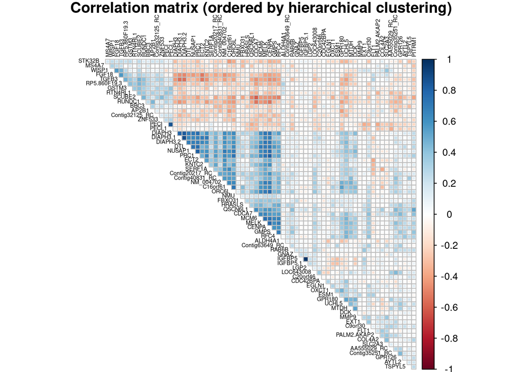

```r
# Correlation plot

corrplot(cor.nika, order="hclust", diag=FALSE, tl.col="black", tl.cex = 0.45, method = "square" , title="Correlation matrix (ordered by hierarchical clustering)", type = 'upper', mar=c(0,0,1,0))
```

It’s a strain to eyes to be reading and assimilating a correlation plot with 70 genes, so it may be better to get the unique set of pairs with a correlation greater than absolute 0.8

```r
# Find the unique set of pairs with correlation greater than 0.8
gene_1 = c()
gene_2 = c()
corr = c()

for (i in 1:dim(cor.nika)[1]){
  for (j in 1:dim(cor.nika)[2]){

    if(abs(cor.nika[i,j]) > 0.8 & cor.nika[i,j] !=1){
      corr <- c(corr, cor.nika[i,j])
      gene_1 <- c(gene_1, rownames(cor.nika)[i])
      gene_2 <- c(gene_2, colnames(cor.nika)[j])
    }
  }
}

gene.corr <- data.table(gene_1[!duplicated(corr,which=T)], gene_2[!duplicated(corr,which=T)], corr[!duplicated(corr,which=T)])

setnames(gene.corr, c("gene_1", "gene_2", "corr"))

gene.corr
```

```
##      gene_1   gene_2      corr
## 1:   DIAPH3 DIAPH3.1 0.8031368
## 2:   DIAPH3 DIAPH3.2 0.8338591
## 3:   NUSAP1     PRC1 0.8298356
## 4: DIAPH3.1 DIAPH3.2 0.8868741
## 5:     PECI   PECI.1 0.8697836
## 6:   IGFBP5 IGFBP5.1 0.9775030
## 7:     PRC1    CENPA 0.8175424
```

### Problem 3.b (8 points)

Run PCA (only over the columns containing gene expressions), in order to derive a patient-wise summary of all gene expressions (dimensionality reduction). Decide which components to keep and justify your decision. Test if those principal components are associated with the outcome in unadjusted logistic regression models and in models adjusted for age, estrogen receptor and grade. Justify the difference in results between unadjusted and adjusted models.

```r
# Run PCA over the gene variables

pca.vars <- prcomp(genes, center = T, scale = T)

# Display the summary of the PCA and the percentage explained
summary(pca.vars)
```

```
## Importance of components:
##                           PC1     PC2     PC3     PC4     PC5     PC6     PC7
## Standard deviation     4.1171 2.30541 2.02437 1.78597 1.73982 1.68091 1.42309
## Proportion of Variance 0.2422 0.07593 0.05854 0.04557 0.04324 0.04036 0.02893
## Cumulative Proportion  0.2422 0.31808 0.37662 0.42219 0.46543 0.50580 0.53473
##                            PC8     PC9   PC10    PC11    PC12    PC13    PC14
## Standard deviation     1.36441 1.29119 1.2715 1.24741 1.18388 1.15101 1.13883
## Proportion of Variance 0.02659 0.02382 0.0231 0.02223 0.02002 0.01893 0.01853
## Cumulative Proportion  0.56132 0.58514 0.6082 0.63046 0.65049 0.66941 0.68794
##                           PC15    PC16    PC17    PC18    PC19    PC20    PC21
## Standard deviation     1.09473 1.07016 1.04187 1.00234 0.99086 0.94095 0.93322
## Proportion of Variance 0.01712 0.01636 0.01551 0.01435 0.01403 0.01265 0.01244
## Cumulative Proportion  0.70506 0.72142 0.73693 0.75128 0.76531 0.77796 0.79040
##                           PC22    PC23    PC24    PC25    PC26    PC27    PC28
## Standard deviation     0.90727 0.89675 0.88859 0.86019 0.84462 0.82782 0.82368
## Proportion of Variance 0.01176 0.01149 0.01128 0.01057 0.01019 0.00979 0.00969
## Cumulative Proportion  0.80216 0.81364 0.82492 0.83549 0.84569 0.85548 0.86517
##                           PC29    PC30    PC31    PC32    PC33    PC34   PC35
## Standard deviation     0.78694 0.75594 0.73942 0.70569 0.69414 0.67129 0.6639
## Proportion of Variance 0.00885 0.00816 0.00781 0.00711 0.00688 0.00644 0.0063
## Cumulative Proportion  0.87401 0.88218 0.88999 0.89710 0.90399 0.91042 0.9167
##                           PC36    PC37    PC38    PC39    PC40    PC41    PC42
## Standard deviation     0.63815 0.61964 0.59947 0.58447 0.57195 0.55097 0.53820
## Proportion of Variance 0.00582 0.00549 0.00513 0.00488 0.00467 0.00434 0.00414
## Cumulative Proportion  0.92254 0.92802 0.93316 0.93804 0.94271 0.94705 0.95118
##                           PC43    PC44    PC45    PC46    PC47    PC48    PC49
## Standard deviation     0.52029 0.51211 0.49533 0.48712 0.47079 0.44565 0.41879
## Proportion of Variance 0.00387 0.00375 0.00351 0.00339 0.00317 0.00284 0.00251
## Cumulative Proportion  0.95505 0.95880 0.96230 0.96569 0.96886 0.97170 0.97420
##                           PC50    PC51   PC52    PC53    PC54    PC55    PC56
## Standard deviation     0.40556 0.39328 0.3925 0.38502 0.36669 0.36205 0.33734
## Proportion of Variance 0.00235 0.00221 0.0022 0.00212 0.00192 0.00187 0.00163
## Cumulative Proportion  0.97655 0.97876 0.9810 0.98308 0.98500 0.98687 0.98850
##                           PC57    PC58    PC59    PC60    PC61    PC62    PC63
## Standard deviation     0.32150 0.30744 0.28898 0.28186 0.27274 0.25622 0.24118
## Proportion of Variance 0.00148 0.00135 0.00119 0.00113 0.00106 0.00094 0.00083
## Cumulative Proportion  0.98998 0.99133 0.99252 0.99365 0.99472 0.99565 0.99649
##                           PC64    PC65    PC66    PC67    PC68   PC69    PC70
## Standard deviation     0.23024 0.21442 0.19886 0.19371 0.17927 0.1677 0.09833
## Proportion of Variance 0.00076 0.00066 0.00056 0.00054 0.00046 0.0004 0.00014
## Cumulative Proportion  0.99724 0.99790 0.99846 0.99900 0.99946 0.9999 1.00000
```

```r
perc.expl <- pca.vars$sdev^2 / sum(pca.vars$sdev^2)

cat("Sum of variance fraction explained in the first 2 components: ", sum(perc.expl[1:2]))
```

```
## Sum of variance fraction explained in the first 2 components:  0.3180793
```

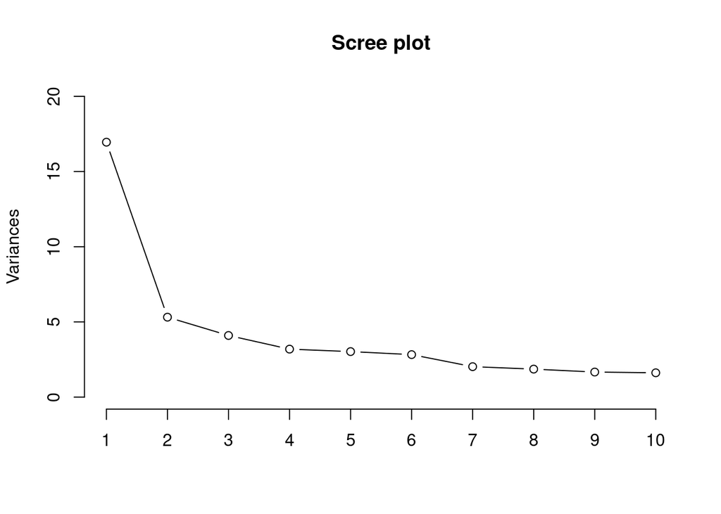

```r
screeplot(pca.vars, main="Scree plot", ylim = c(0, 20), type = "lines")
```

```r
#install.packages("factoextra")

library(factoextra)
```

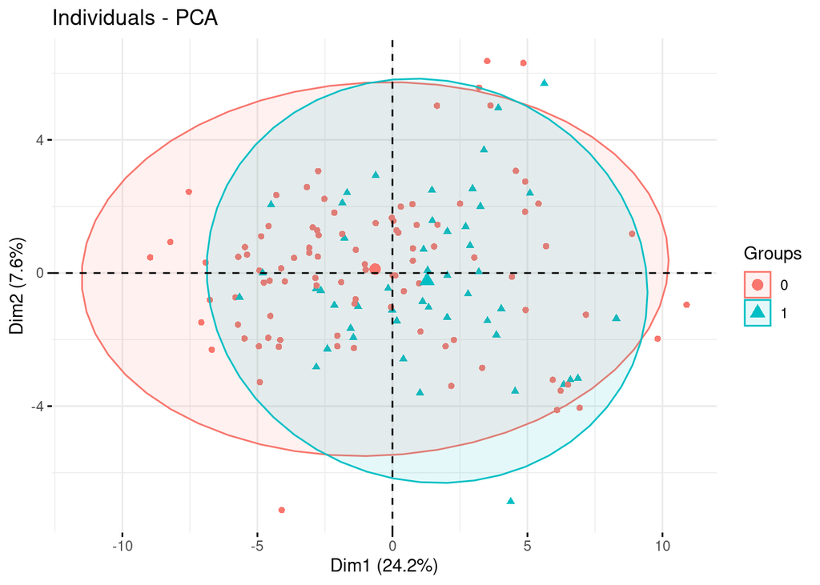

```r
fviz_pca_ind(pca.vars, geom='point', habillage = nika.dt$Event, axes = c(1,2), addEllipses = T)
```

```r
eig.val <- get_eigenvalue(pca.vars)
eig.val
```

```
##          eigenvalue variance.percent cumulative.variance.percent
## Dim.1  16.950630477      24.21518640                    24.21519
## Dim.2   5.314919533       7.59274219                    31.80793
## Dim.3   4.098066841       5.85438120                    37.66231
## Dim.4   3.189698174       4.55671168                    42.21902
## Dim.5   3.026989952       4.32427136                    46.54329
## Dim.6   2.825470593       4.03638656                    50.57968
## Dim.7   2.025198406       2.89314058                    53.47282
## Dim.8   1.861620769       2.65945824                    56.13228
## Dim.9   1.667183354       2.38169051                    58.51397
## Dim.10  1.616735711       2.30962244                    60.82359
## Dim.11  1.556029821       2.22289974                    63.04649
## Dim.12  1.401563584       2.00223369                    65.04872
## Dim.13  1.324831451       1.89261636                    66.94134
## Dim.14  1.296928607       1.85275515                    68.79410
## Dim.15  1.198430094       1.71204299                    70.50614
## Dim.16  1.145233578       1.63604797                    72.14219
## Dim.17  1.085492405       1.55070344                    73.69289
## Dim.18  1.004685341       1.43526477                    75.12816
## Dim.19  0.981805888       1.40257984                    76.53074
## Dim.20  0.885385811       1.26483687                    77.79557
## Dim.21  0.870892333       1.24413190                    79.03970
## Dim.22  0.823132792       1.17590399                    80.21561
## Dim.23  0.804167549       1.14881078                    81.36442
## Dim.24  0.789583860       1.12797694                    82.49240
## Dim.25  0.739933753       1.05704822                    83.54944
## Dim.26  0.713385022       1.01912146                    84.56857
## Dim.27  0.685290463       0.97898638                    85.54755
## Dim.28  0.678453263       0.96921895                    86.51677
## Dim.29  0.619274625       0.88467804                    87.40145
## Dim.30  0.571449209       0.81635601                    88.21780
## Dim.31  0.546735089       0.78105013                    88.99885
## Dim.32  0.498004401       0.71143486                    89.71029
## Dim.33  0.481834340       0.68833477                    90.39862
## Dim.34  0.450635905       0.64376558                    91.04239
## Dim.35  0.440732533       0.62961790                    91.67201
## Dim.36  0.407234079       0.58176297                    92.25377
## Dim.37  0.383954815       0.54850688                    92.80228
## Dim.38  0.359361159       0.51337308                    93.31565
## Dim.39  0.341605753       0.48800822                    93.80366
```

[output cut: 16 more lines]

```
## Dim.56  0.113795404       0.16256486                    98.84994
## Dim.57  0.103363088       0.14766155                    98.99760
## Dim.58  0.094517355       0.13502479                    99.13263
## Dim.59  0.083507072       0.11929582                    99.25193
## Dim.60  0.079447516       0.11349645                    99.36542
## Dim.61  0.074387575       0.10626796                    99.47169
## Dim.62  0.065648420       0.09378346                    99.56547
## Dim.63  0.058168202       0.08309743                    99.64857
## Dim.64  0.053011627       0.07573090                    99.72430
## Dim.65  0.045976478       0.06568068                    99.78998
## Dim.66  0.039545228       0.05649318                    99.84648
## Dim.67  0.037522418       0.05360345                    99.90008
## Dim.68  0.032139494       0.04591356                    99.94599
## Dim.69  0.028136339       0.04019477                    99.98619
## Dim.70  0.009669034       0.01381291                   100.00000
```

We can use the screeplot and the percentage of variance explained per principal score to see that the explained variances flatten after the 6th component. PC 7 does not offer representative benefit as it only captures 2.89% of variances. The number of components to take in this case is 6, and it captures only 50.57% of the variance in the dataset.

```r
cat("Sum of variance fraction explained in the first 6 components: ", sum(perc.expl[1:6]))
```

```
## Sum of variance fraction explained in the first 6 components:  0.5057968
```

```r
# Unadjusted models using first 6 components

#pca.vars$rotation[,1:6]
sort(pca.vars$rotation[,1:6], decreasing = TRUE)
```

```
##   [1]  0.3442430971  0.3406638500  0.3358983996  0.2869099518  0.2741498286
##   [6]  0.2735517147  0.2608513132  0.2557049137  0.2389926207  0.2265872360
##  [11]  0.2212464501  0.2130017594  0.2086195626  0.2068466410  0.2034727145
##  [16]  0.2030517089  0.2016043958  0.1969747635  0.1963327099  0.1933070731
##  [21]  0.1920986998  0.1908166575  0.1898039069  0.1885517375  0.1874029536
##  [26]  0.1851384672  0.1837358335  0.1819548974  0.1800494978  0.1784956506
##  [31]  0.1782456346  0.1773430970  0.1763281341  0.1749786054  0.1741104887
##  [36]  0.1736822502  0.1716404556  0.1715154753  0.1707437491  0.1697652144
##  [41]  0.1686303726  0.1684569918  0.1680983395  0.1663381799  0.1631554727
##  [46]  0.1587895474  0.1573814759  0.1566911999  0.1562972776  0.1539292709
##  [51]  0.1529319373  0.1501226748  0.1490965522  0.1483733203  0.1479349438
##  [56]  0.1467843592  0.1445326689  0.1442508735  0.1439098043  0.1436662738
##  [61]  0.1427757343  0.1420421896  0.1417366415  0.1404533122  0.1393843829
##  [66]  0.1393430733  0.1386290007  0.1380494322  0.1351182323  0.1346748018
##  [71]  0.1339791738  0.1333589993  0.1316467275  0.1286967663  0.1246599899
```

[output cut: 69 more lines]

### Problem 3.c (8 points)

Use plots to compare with the correlation structure observed in problem 2.a and to examine how well the dataset may explain your outcome. Discuss your findings and suggest any further steps if needed.

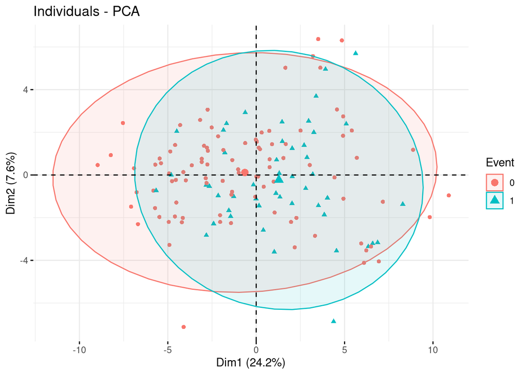

```r
fviz_pca_ind(pca.vars, geom='point',col.ind = as.factor(nika.dt$Event), axes = c(1,2), addEllipses = T, legend.title = "Event")
```

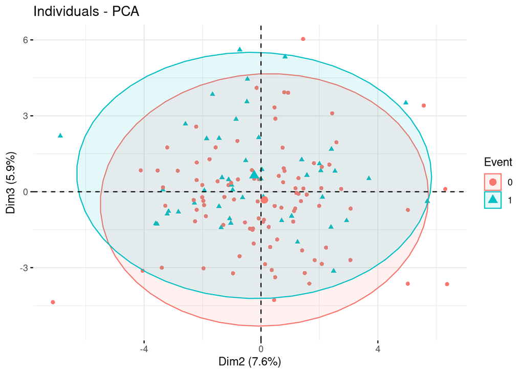

```r
fviz_pca_ind(pca.vars, geom='point', axes = c(2,3), col.ind = as.factor(nika.dt$Event), addEllipses = T, legend.title = "Event")
```

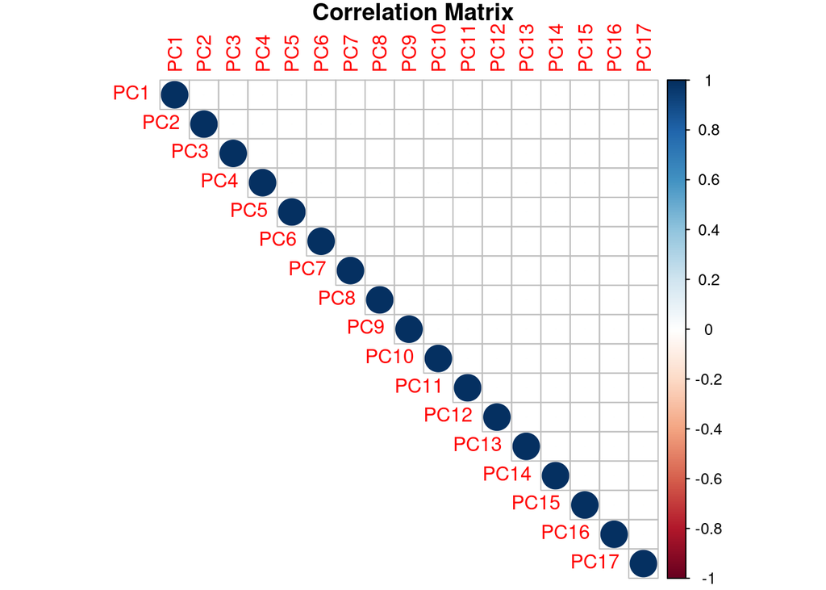

```r
num_pca = 17
cor.new = pca.vars$x[,1:num_pca] %>% cor(use = "pairwise.complete")
corrplot(cor.new, diag = TRUE, t1.col = "black", t1.cex =0.6, title = "Correlation Matrix", type = "upper", mar = c(0,0,1,0))
```

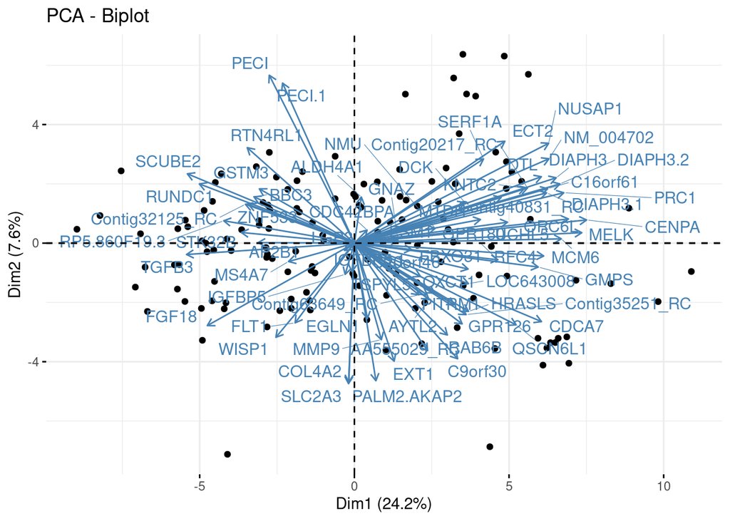

```r
options(ggrepel.max.overlaps = Inf)
fviz_pca_biplot(pca.vars, geom ='point', repel = T)
```

We can see that from our observations that the first component assings large positive values to gene expressions (ENPA, MELK, ORC6L, PRC1, and MCMG and large negative values to gene expression TGFB3, SCUBE2, RUNDC1, FGF18). It is fairly easy to see that these gene expressions have most influence on PC1. On the contrary, the second component analysis assigns large positive values to gene expression PEC, PECI.1, ECT2, and NSUAP1, and large negative values values to gene expressions SLC2A3, COL 4A2, and PALM2.AKAP2; this second set of gene expressions has most influence on PC 2.

From the biplot we can read the correlations between gene expressions.

Angles of arrows < 90 : Highly correlated Angles of arrows = 90 : Not correlated Angles of arrows > 90 : Higly negatively correlated

Thus,observing the biplot we can consolidate our observations from Q2a. Angles are <90 between DIAPH3, DIAP3H3.1 and DIAPH3.2 in additon to PECI and PECI.1 or MELK, CENPA, ORCI6, and PRC1 and angles are >90 degrees between DIAPH3.1, DIAPH3.2 and TGFB3.

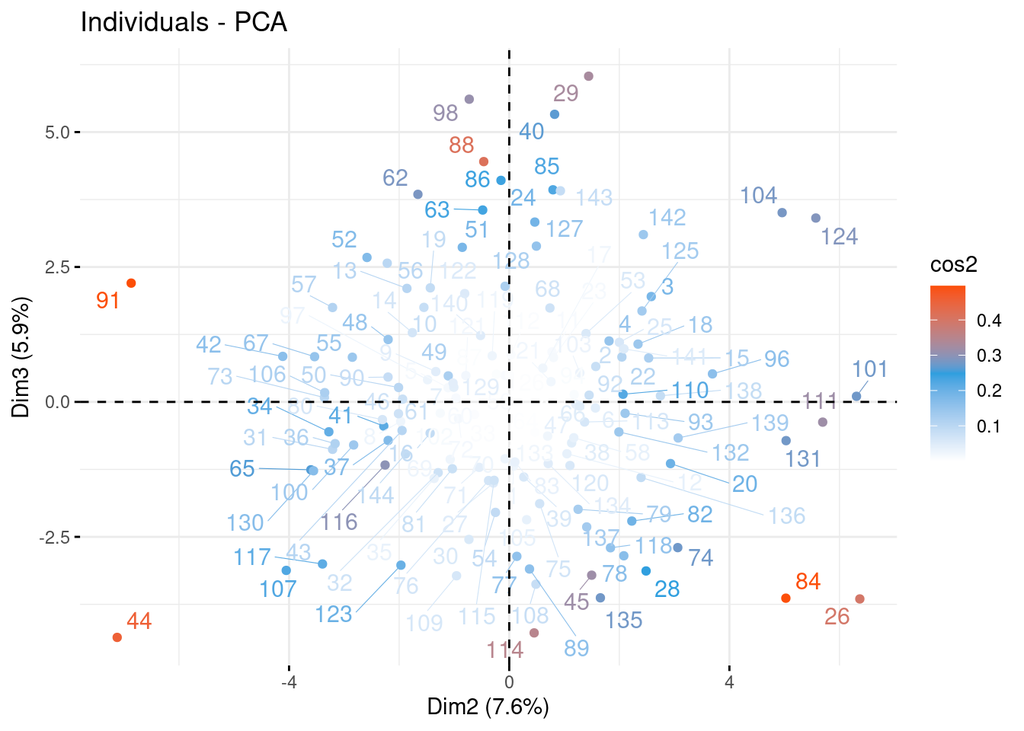

```r
#Another helpful visualisation
fviz_pca_ind(pca.vars,axes = c(2,3), col.ind = "cos2",gradient.cols = c("white", "#2E9FDF", "#FC4E07"), repel = T)
```

### Problem 3.d (11 points)

Based on the models we examined in the labs, fit an appropriate model with the aim to provide the most accurate prognosis you can for patients. Discuss and justify your decisions.

```r
set.seed(984065)

predictor_gene = as.matrix(nika.dt[,c(1,2,3,4,5,6)])
result = nika.dt$Event

#Make a splitting Index

Splitting_index_new  <- createDataPartition(result, p = 0.7)$Resample1

#Training and testing data set
x_train_nika.dt <- predictor_gene[Splitting_index_new,]
x_test_nika.dt <- predictor_gene[-Splitting_index_new,]
y_train_nika.dt <- result[Splitting_index_new]
length(y_train_nika.dt)
```

```
## [1] 101
```

```r
y_test_nika.dt <- result[-Splitting_index_new ]

train_nika.dt = nika.dt[Splitting_index_new,]
test_nika.dt  = nika.dt[-Splitting_index_new, ]


#fit.cv.lasso = cv.glmnet(x_train_nika.dt, y_train_nika.dt, alpha = 0, family = "binomial",type.measure = "auc")

#fit.cv.ridge = cv.glmnet(x_train_nika.dt, y_train_nika.dt, alpha = 1,family = "binomial",type.measure ="auc")

#Full and Null model

full_model_nika <- glm(Event ~., data = train_nika.dt, family = binomial(link = "logit"))

null_model_nika <- glm(Event ~ 1, data = train_nika.dt, family = binomial(link = "logit"))

#Forward and backward models
model.nika.forward <- stepAIC(null_model_nika, scope=list(upper=full_model_nika), direction="forward")
```

```
## Start:  AIC=132.35
## Event ~ 1
##
##                    Df Deviance    AIC
## + LymphNodes        1   122.49 126.49
## + NUSAP1            1   122.94 126.94
## + QSCN6L1           1   123.47 127.47
## + PRC1              1   123.76 127.76
## + EGLN1             1   124.39 128.39
## + Contig63649_RC    1   124.61 128.61
## + CENPA             1   124.97 128.97
## + LGP2              1   125.21 129.21
## + ORC6L             1   125.61 129.61
## + NM_004702         1   125.96 129.96
## + ZNF533            1   126.41 130.41
## + IGFBP5            1   126.42 130.42
## + MELK              1   126.64 130.64
## + IGFBP5.1          1   126.64 130.64
## + RFC4              1   126.79 130.79
## + GNAZ              1   127.39 131.39
## + ALDH4A1           1   127.42 131.42
## + Diam              1   127.50 131.50
## + MMP9              1   127.50 131.50
## + GMPS              1   127.54 131.54
## + PECI.1            1   127.55 131.55
## + MS4A7             1   127.70 131.70
## + STK32B            1   127.81 131.81
## + GPR180            1   127.82 131.82
## + COL4A2            1   127.83 131.83
## + UCHL5             1   127.94 131.94
## + DTL               1   128.02 132.02
## + ECT2              1   128.08 132.08
## + Age               1   128.15 132.15
## + C9orf30           1   128.17 132.17
## <none>                  130.35 132.35
## + CDCA7             1   128.38 132.38
## + RTN4RL1           1   128.48 132.48
## + DIAPH3.2          1   128.66 132.66
## + PECI              1   128.75 132.75
## + DIAPH3            1   128.94 132.94
```

[output cut: 1526 more lines]

```
## + IGFBP5.1          1     0.00  46.00
## + SERF1A            1     0.00  46.00
## + SLC2A3            1     0.00  46.00
## + AYTL2             1     0.00  46.00
## + PECI              1     0.00  46.00
## + SCUBE2            1     0.00  46.00
## + EXT1              1     0.00  46.00
## + MTDH              1     0.00  46.00
## + C9orf30           1     0.00  46.00
## + AA555029_RC       1     0.00  46.00
## + RAB6B             1     0.00  46.00
## + CDC42BPA          1     0.00  46.00
## + FBXO31            1     0.00  46.00
## + Grade             2     0.00  48.00
## + NM_004702         1   648.79 694.79
```

```r
#We rely on Q1, as model B and S performed the best, we will be moving forward with them for this question as well.
```

We can see that the AIC values for the forward model start from 132.35 and the lowest AIC obtained is 44

```r
model.nika.backward <- stepAIC(full_model_nika, direction ="backward")
```

```
## Start:  AIC=154
## Event ~ Diam + LymphNodes + EstrogenReceptor + Grade + Age +
##     TSPYL5 + Contig63649_RC + DIAPH3 + NUSAP1 + AA555029_RC +
##     ALDH4A1 + QSCN6L1 + FGF18 + DIAPH3.1 + Contig32125_RC + BBC3 +
##     DIAPH3.2 + RP5.860F19.3 + C16orf61 + SCUBE2 + EXT1 + FLT1 +
##     GNAZ + OXCT1 + MMP9 + RUNDC1 + Contig35251_RC + ECT2 + GMPS +
##     KNTC2 + WISP1 + CDC42BPA + SERF1A + AYTL2 + GSTM3 + GPR180 +
##     RAB6B + ZNF533 + RTN4RL1 + UCHL5 + PECI + MTDH + Contig40831_RC +
##     TGFB3 + MELK + COL4A2 + DTL + STK32B + DCK + FBXO31 + GPR126 +
##     SLC2A3 + PECI.1 + ORC6L + RFC4 + CDCA7 + LOC643008 + MS4A7 +
##     MCM6 + AP2B1 + C9orf30 + IGFBP5 + HRASLS + PITRM1 + IGFBP5.1 +
##     NMU + PALM2.AKAP2 + LGP2 + PRC1 + Contig20217_RC + CENPA +
##     EGLN1 + NM_004702 + ESM1 + C20orf46
##
##                    Df   Deviance AIC
## - Grade             2 1.3930e-09 150
## - DIAPH3            1 1.3041e-09 152
## - EXT1              1 1.3043e-09 152
## - Contig35251_RC    1 1.3053e-09 152
## - EstrogenReceptor  1 1.3062e-09 152
## - FBXO31            1 1.3071e-09 152
## - COL4A2            1 1.3080e-09 152
## - NMU               1 1.3087e-09 152
## - CDC42BPA          1 1.3090e-09 152
## - ECT2              1 1.3091e-09 152
## - AA555029_RC       1 1.3096e-09 152
## - Age               1 1.3101e-09 152
## - C9orf30           1 1.3107e-09 152
## - CDCA7             1 1.3108e-09 152
## - SERF1A            1 1.3112e-09 152
## - GSTM3             1 1.3121e-09 152
## - ORC6L             1 1.3128e-09 152
## - RUNDC1            1 1.3132e-09 152
## - AP2B1             1 1.3134e-09 152
## - Contig20217_RC    1 1.3135e-09 152
## - ZNF533            1 1.3139e-09 152
## - GNAZ              1 1.3145e-09 152
## - RFC4              1 1.3146e-09 152
## - GMPS              1 1.3154e-09 152
## - MELK              1 1.3157e-09 152
```

[output cut: 3287 more lines]

```
## - MCM6            1   44.449 86.449
## - C16orf61        1   44.816 86.816
## - IGFBP5          1   45.088 87.088
## - LGP2            1   46.204 88.204
## - FGF18           1   46.497 88.497
## - LOC643008       1   46.574 88.574
## - OXCT1           1   50.068 92.068
## - KNTC2           1   50.319 92.319
## - HRASLS          1   50.872 92.872
## - Contig32125_RC  1   50.980 92.980
## - LymphNodes      1   51.955 93.955
## - PECI.1          1   52.005 94.005
## - UCHL5           1   52.094 94.094
## - STK32B          1   54.506 96.506
## - Contig63649_RC  1   56.760 98.760
```